# 2024 NH3-loss Statistical Models, cube root

The marginally non-significant interaction between rainfall and temperature can be interpreted as the slope of air temperature increasing in steepness with increasing rainfall. This means that the effect of temperature is dependent on rainfall, and temperature only has an effect when rain is present.

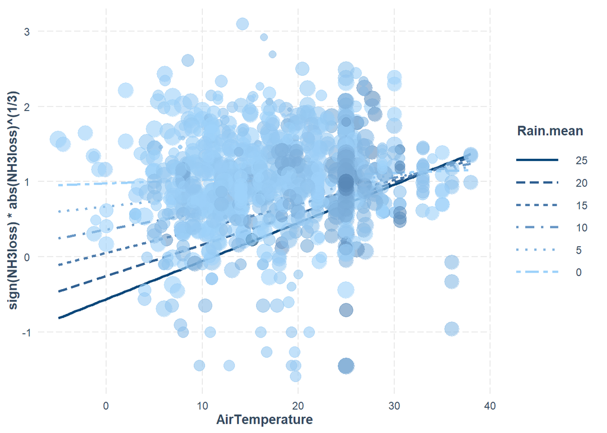

Similarly, the interaction can be interpreted from the perspective of rain: The association between rain and NH3 emissions changes from negative to slightly positive with increasing temperature.

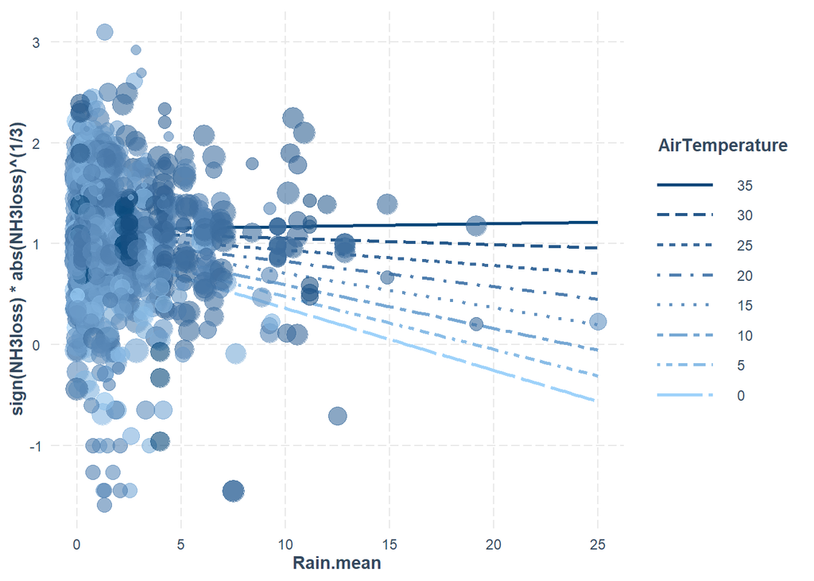

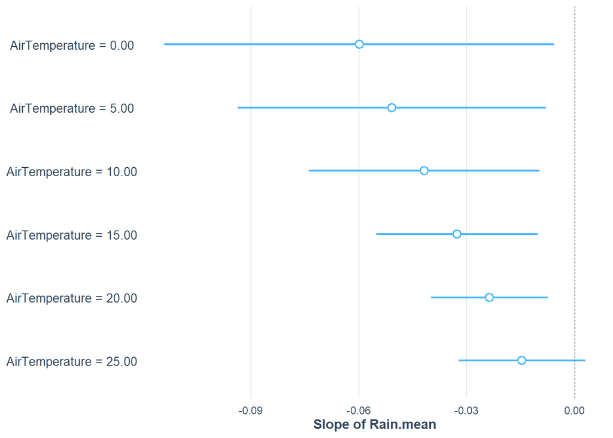

```
## JOHNSON-NEYMAN INTERVAL
##
## When AirTemperature is INSIDE the interval [-15.81, 24.32], the slope of
## Rain.mean is p < .05.
##
## Note: The range of observed values of AirTemperature is [-5.00, 38.00]
```

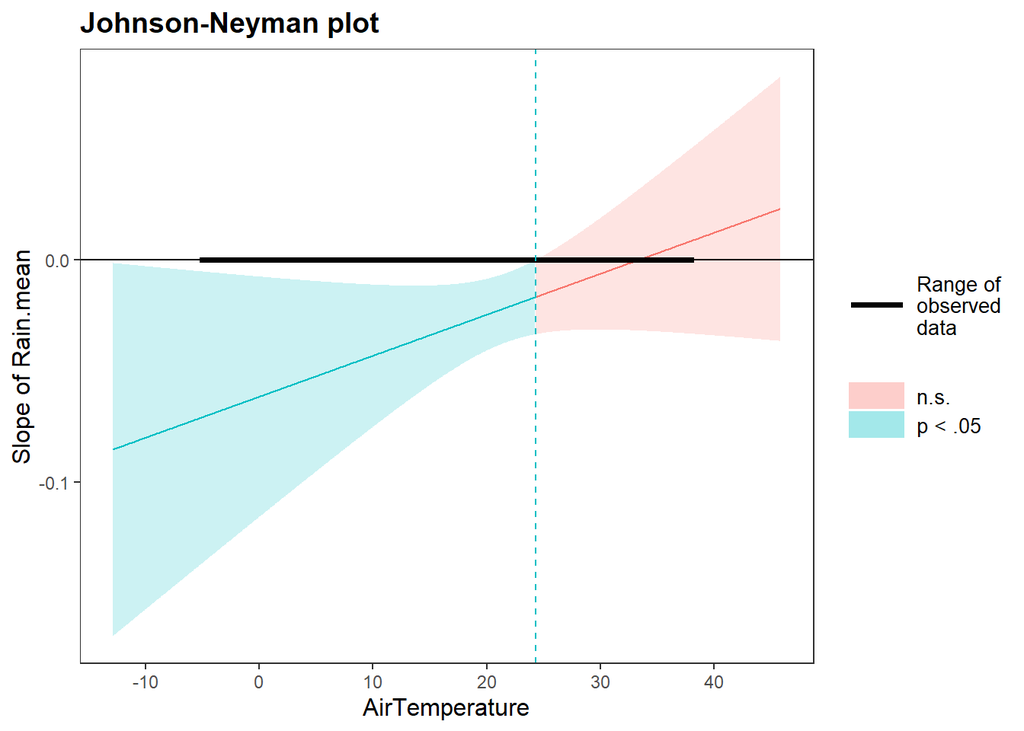

### A_Air temperature

Considering air temperature separately, there is a statistically significant effect of air temperature (F(1, 1887) =9.7, p = 0.002). Adjusted R2-value of the model was 0.00458, and multiple R2 was 0.00511. This means air temperature explains 0.458 % of the variation.

There are 1889 observations in the analysis.

The full model output with the slopes and their standard error can be seen below:

```
##
## Call:
## lm(formula = sign(NH3loss) * abs(NH3loss)^(1/3) ~ AirTemperature +
##     offset(M1_fit), data = NH3predict_m7_2, weights = Weight)
##
## Weighted Residuals:
##     Min      1Q  Median      3Q     Max
## -7.5821 -0.7345  0.0661  0.8172  4.5888
##
## Coefficients:
##                 Estimate Std. Error t value Pr(>|t|)
## (Intercept)    -0.113765   0.038968  -2.919  0.00355 **
## AirTemperature  0.005795   0.001861   3.114  0.00187 **
## ---
## Signif. codes:  0 '***' 0.001 '**' 0.01 '*' 0.05 '.' 0.1 ' ' 1
##
## Residual standard error: 1.342 on 1887 degrees of freedom
## Multiple R-squared:  0.005112,   Adjusted R-squared:  0.004585
## F-statistic: 9.696 on 1 and 1887 DF,  p-value: 0.001875
```

### A_Air temperature over first 7 days

There is no statistically significant effect of air temperature over the first 7 days of the experiment (F(1, 179) =1.89, p = 0.17). Adjusted R2-value of the model was 0.00494, and multiple R2 was 0.01047. This means air temperature over the first 7 days explains 0.494 % of the variation.

There are 181 observations in the analysis.

The full model output with the slopes and their standard error can be seen below:

```
##
## Call:
## lm(formula = sign(NH3loss) * abs(NH3loss)^(1/3) ~ Temp.7d + offset(M1_fit),
##     data = NH3predict_mA7, weights = Weight)
##
## Weighted Residuals:
##     Min      1Q  Median      3Q     Max
## -4.8924 -0.5921  0.2718  1.0711  3.0775
##
## Coefficients:
##              Estimate Std. Error t value Pr(>|t|)
## (Intercept)  0.148175   0.115762   1.280    0.202
## Temp.7d     -0.010176   0.007394  -1.376    0.170
##
## Residual standard error: 1.624 on 179 degrees of freedom
## Multiple R-squared:  0.01047,    Adjusted R-squared:  0.004943
## F-statistic: 1.894 on 1 and 179 DF,  p-value: 0.1705
```

### A_Mean daily rainfall

Considering mean rainfall separately, there is no statistically significant effect of rain (F(1, 1036) =2.69, p = 0.101). Adjusted R2-value of the model was 0.00163, and multiple R2 was 0.00259. Thus, rainfall doesn’t meaningfully explain any variation in the data.

There are 1038 observations in the analysis.

The full model output with the slopes and their standard error can be seen below:

```
##
## Call:
## lm(formula = sign(NH3loss) * abs(NH3loss)^(1/3) ~ Rain.mean +
##     offset(M1_fit), data = NH3predict_m8, weights = Weight)
##
## Weighted Residuals:
##     Min      1Q  Median      3Q     Max
## -5.3198 -0.7494  0.0591  0.8228  4.1376
##
## Coefficients:
##              Estimate Std. Error t value Pr(>|t|)
## (Intercept)  0.023874   0.025281   0.944    0.345
## Rain.mean   -0.011815   0.007205  -1.640    0.101
##
## Residual standard error: 1.303 on 1036 degrees of freedom
## Multiple R-squared:  0.002589,   Adjusted R-squared:  0.001626
## F-statistic: 2.689 on 1 and 1036 DF,  p-value: 0.1013
```

### A_Rainfall over first 72 h

There is no statistically significant effect of rainfall during the first 72h of the experiment (F(1, 671) =0.7, p = 0.403). Adjusted R2-value of the model was -4.5^{-4}, and multiple R2 was 0.00104. Thus, rainfall during the first 72h doesn’t meaningfully explain any variation in the data.

There are 673 observations in the analysis.

The full model output with the slopes and their standard error can be seen below:

```
##
## Call:
## lm(formula = sign(NH3loss) * abs(NH3loss)^(1/3) ~ Rain.72h +
##     offset(M1_fit), data = NH3predict_R8, weights = Weight)
##
## Weighted Residuals:
##     Min      1Q  Median      3Q     Max
## -5.4824 -0.7639  0.0949  0.8874  4.2206
##
## Coefficients:
##              Estimate Std. Error t value Pr(>|t|)
## (Intercept)  0.008147   0.027858   0.292    0.770
## Rain.72h    -0.001406   0.001680  -0.837    0.403
##
## Residual standard error: 1.389 on 671 degrees of freedom
## Multiple R-squared:  0.001043,   Adjusted R-squared:  -0.0004455
## F-statistic: 0.7007 on 1 and 671 DF,  p-value: 0.4028
```

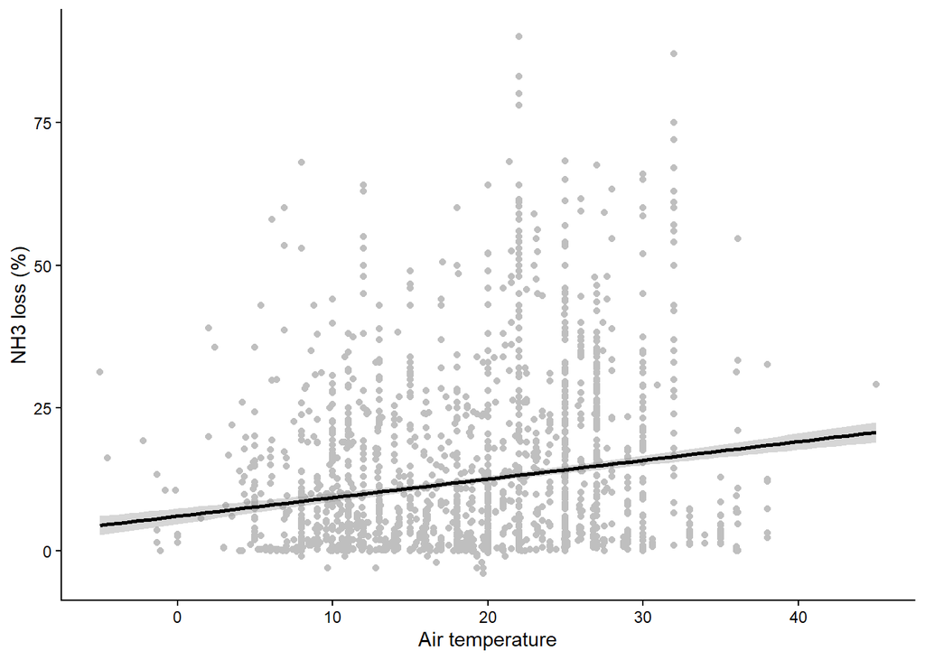

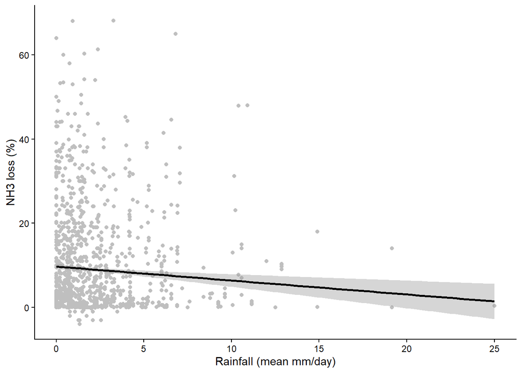